# Worldwide projections

# Background/Aim

The aim of this short piece of research will be to investigate whether, given current trends, the number of cases will exceed the world population, and if so when, and if not what the expected total confirmed infected will be given current trends and current trends. The secondary aim is to do the same for confirmed deaths, and to extimate the final projected CFRs.

# Data

```r
pacman::p_load(lubridate,here,  ggrepel,tidyverse)
```

Now use time series and link to file

```r
url_confirmed <- "https://raw.githubusercontent.com/CSSEGISandData/COVID-19/master/csse_covid_19_data/csse_covid_19_time_series/time_series_covid19_confirmed_global.csv"

url_deaths <- "https://raw.githubusercontent.com/CSSEGISandData/COVID-19/master/csse_covid_19_data/csse_covid_19_time_series/time_series_covid19_deaths_global.csv"


url_recovered <- "https://raw.githubusercontent.com/CSSEGISandData/COVID-19/master/csse_covid_19_data/csse_covid_19_time_series/time_series_covid19_recovered_global.csv"
```

```r
n_confirmed <-
  read_csv(url_confirmed) %>%
    select(-Lat, -Long) %>%
    rename(
      lower = `Province/State`,
      higher = `Country/Region`
    ) %>%
    gather(-lower, -higher, key = "date", value = "n_confirmed") %>%
    mutate(date = mdy(date))
n_recovered <-
  read_csv(url_recovered) %>%
    select(-Lat, -Long) %>%
    rename(
      lower = `Province/State`,
      higher = `Country/Region`
    ) %>%
    gather(-lower, -higher, key = "date", value = "n_recovered") %>%
    mutate(date = mdy(date))
n_deaths <-
  read_csv(url_deaths) %>%
    select(-Lat, -Long) %>%
    rename(
      lower = `Province/State`,
      higher = `Country/Region`
    ) %>%
    gather(-lower, -higher, key = "date", value = "n_deaths") %>%
    mutate(date = mdy(date))
tidied_data <-
  reduce(.x = list(n_confirmed, n_recovered, n_deaths), full_join, by = c("lower", "higher", "date")) %>%
    gather(key = "type", value = "n", n_confirmed:n_deaths) %>%
    mutate(type = str_replace(type, pattern = "^n_", "")) %>%
    replace_na(list(n = 0))
```

Now after Feb 15

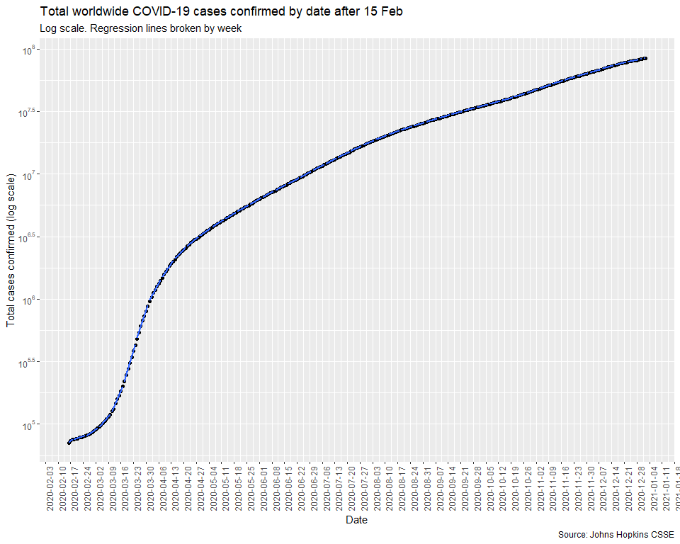

```r
tidied_data %>%
  filter(type == "confirmed") %>%
  filter(date > lubridate::dmy("15-02-2020")) %>%
  group_by(date) %>%
  summarise(total_confirmed = sum(n)) %>%
  ungroup() %>%
  mutate(week = lubridate::week(date)) %>%
  ggplot(aes(x = date, y = total_confirmed)) +
  geom_point()  +
  scale_y_log10(
    breaks = scales::trans_breaks("log10", function(x) 10^x),
    labels = scales::trans_format("log10", scales::math_format(10^.x))
    ) +
  scale_x_date(date_breaks = "1 week") +
  theme(axis.text.x = element_text(angle = 90, hjust = 1)) +
  stat_smooth(
    aes(group = week),
    method = "lm", se = FALSE
  ) +
  labs(
    x = "Date", y = "Total cases confirmed (log scale)",
    title = "Total worldwide COVID-19 cases confirmed by date after 15 Feb",
    subtitle = "Log scale. Regression lines broken by week",
    caption = "Source: Johns Hopkins CSSE"
  )
```

```r
ggsave(here("figures", "covid_19_confirmed_from15feb.png"), height = 20, width = 25, units = "cm", dpi = 300)
```

How about confirmed deaths on same plot?

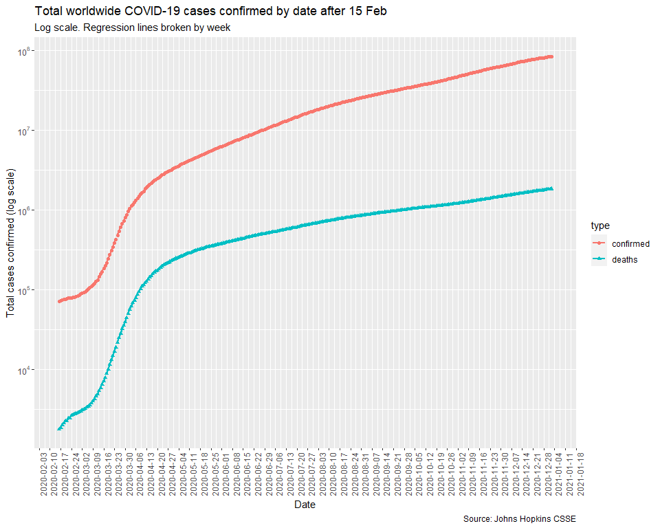

```r
tidied_data %>%
  filter(type %in% c("confirmed", "deaths")) %>%
  filter(date > lubridate::dmy("15-02-2020")) %>%
  group_by(date, type) %>%
  summarise(n = sum(n)) %>%
  ungroup() %>%
  mutate(week = lubridate::week(date)) %>%
  ggplot(aes(x = date, y = n, group = type, colour = type, shape = type)) +
  geom_point()  +
  scale_y_log10(
    breaks = scales::trans_breaks("log10", function(x) 10^x),
    labels = scales::trans_format("log10", scales::math_format(10^.x))
    ) +
  scale_x_date(date_breaks = "1 week") +
  theme(axis.text.x = element_text(angle = 90, hjust = 1)) +
  stat_smooth(
    aes(group = paste0(week, type)),
    method = "lm", se = FALSE
  ) +
  labs(
    x = "Date", y = "Total cases confirmed (log scale)",
    title = "Total worldwide COVID-19 cases confirmed by date after 15 Feb",
    subtitle = "Log scale. Regression lines broken by week",
    caption = "Source: Johns Hopkins CSSE"
  )
```

```r
ggsave(here("figures", "covid_19_confirmed_and_dead_from15feb.png"), height = 20, width = 25, units = "cm", dpi = 300)
```

For each of these weeks, what’s the gradient?

```r
tidied_data %>%
  filter(type %in% c("confirmed", "deaths")) %>%
  filter(date > lubridate::dmy("15-02-2020")) %>%
  group_by(date, type) %>%
  summarise(n = sum(n)) %>%
  ungroup() %>%
  mutate(week = lubridate::week(date))  %>%
  group_by(week, type) %>%
  nest() %>%
  mutate(mod = map(data, ~lm(log(n) ~ date, data = .))) %>%
  mutate(slope = map(mod, ~coef(.) %>% pluck(2))) %>%
  select(week, type, slope) %>%
  unnest() %>%
  ggplot(aes(x = week, y = slope, group = type, shape = type, colour = type)) +
  geom_line() + geom_point()  +
  expand_limits(y = 0)
```

```
`cols` is now required when using unnest().
Please use `cols = c(slope)`
```

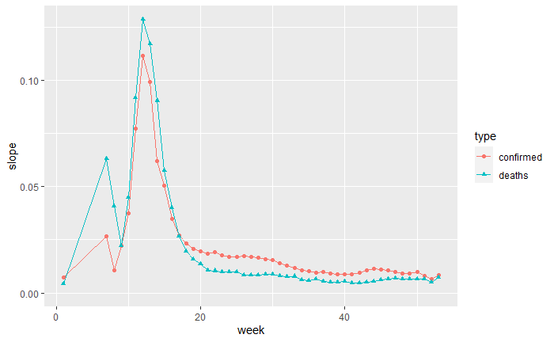

```r
ggsave(here("figures", "weekly_trends_confirmed_deaths.png"), width = 30, height = 20, units = "cm", dpi = 300)
```

Let’s focus in on weeks 17 and onwards

```r
slope_data <-
  tidied_data %>%
    filter(type %in% c("confirmed", "deaths")) %>%
    filter(date > lubridate::dmy("15-02-2020")) %>%
    group_by(date, type) %>%
    summarise(n = sum(n)) %>%
    ungroup() %>%
    mutate(week = lubridate::week(date))  %>%
    filter( week >= 17) %>%
    group_by(week, type) %>%
    nest() %>%
    mutate(mod = map(data, ~lm(log(n) ~ date, data = .))) %>%
    mutate(slope = map(mod, ~coef(.) %>% pluck(2))) %>%
    select(week, type, slope) %>%
    unnest()
```

```
`cols` is now required when using unnest().
Please use `cols = c(slope)`
```

```r
slope_data %>%
  spread(type, slope)
```

| week | confirmed | deaths |
| --- | --- | --- |
| 17 | 0.026935573 | 0.026669200 |
| 18 | 0.023457268 | 0.019757440 |
| 19 | 0.020579636 | 0.015812213 |
| 20 | 0.019595271 | 0.013521006 |
| 21 | 0.018606541 | 0.010525154 |
| 22 | 0.019282825 | 0.010476163 |
| 23 | 0.017706295 | 0.009875050 |
| 24 | 0.016915853 | 0.009783736 |
| 25 | 0.017167760 | 0.009890799 |
| 26 | 0.017395137 | 0.008421935 |

[output cut: 27 more lines]

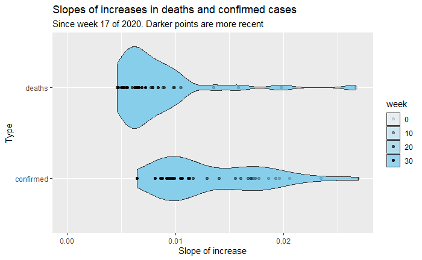

```r
slope_data %>%
  ungroup() %>%
  mutate(week = week - min(week)) %>%
  ggplot(aes(x = slope, group = type,alpha = week)) +
  geom_violin(aes(y = type), fill = "skyblue") +
  geom_point(aes(y = type)) +
  labs(x = "Slope of increase", y = "Type", title = "Slopes of increases in deaths and confirmed cases",
       subtitle = "Since week 17 of 2020. Darker points are more recent") +
  expand_limits(x = 0)
```

Let’s think again about what the slope coefficients could be showing. They point towards a number of different scenarios:

- No slowdown: Since around week 21 the slopes have been roughly the same
- Continual slowdown: Since around week 21 both have been slowing
- Recent slowdown: Between around weeks 21-21 slopes were roughly the same, but since they have both been declining.

Let’s produce some projections based on each of these scenarios, then start to consider how they compare over the next few weeks. * World population: 7.8 * 10^9